# Sabatina,

## *text mining reviews - The Wolf of Wall Street*

> - [Emerson Rigoni](http://lattes.cnpq.br/9410653573760282)
> - Henrique Aparecido Laureano [[GitLab](https://gitlab.c3sl.ufpr.br/u/hal11), [GitHub](https://github.com/mynameislaure), [Lattes](http://lattes.cnpq.br/2224901552085090)]

### Junho de 2016

[figure not shown]

### Dataset: 50 comentários sobre o filme no IMDb

```r
# tm: text mining package
library(tm)

# lendo os dados
path <- "C:/Users/henri/Dropbox/ce062/text_mining-sabatina7/the_wolf_of_wall_street"

dados <- Corpus(DirSource(path))

# <preprocessamento>
## removendo pontuação e outros caracteres especiais
dados <- tm_map(dados, removePunctuation)

## removendo números
dados <- tm_map(dados, removeNumbers)

## deixando tudo em minúsculo
dados <- tm_map(dados, tolower)

## removendo palavras de ligação sem valor analítico
### stopwords("english")
dados <- tm_map(dados, removeWords, stopwords("english"))

## removendo finais de conjugação e tempos das palavras, e.g., "ing", "es", "s"
library(SnowballC)
dados <- tm_map(dados, stemDocument)

## removendo espaços desnecessários
dados <- tm_map(dados, stripWhitespace)

## removendo palavras desnecessárias
dados <- tm_map(dados, removeWords, c("film","movie", "wolf", "wall", "street"))

## deixando os dados prontos pra serem usados
dados <- tm_map(dados, PlainTextDocument)

dados <- DocumentTermMatrix(dados)
# </preprocessamento>

# as 10 palavras que mais aparecem nos comentários e quantas vezes elas aparecem
head(freq <- sort(colSums(as.matrix(dados)), decreasing = TRUE), 10)
```

```
 belfort scorsese dicaprio     like     just      one   people     even   really   scenes
      60       60       59       54       50       49       39       38       37       36
```

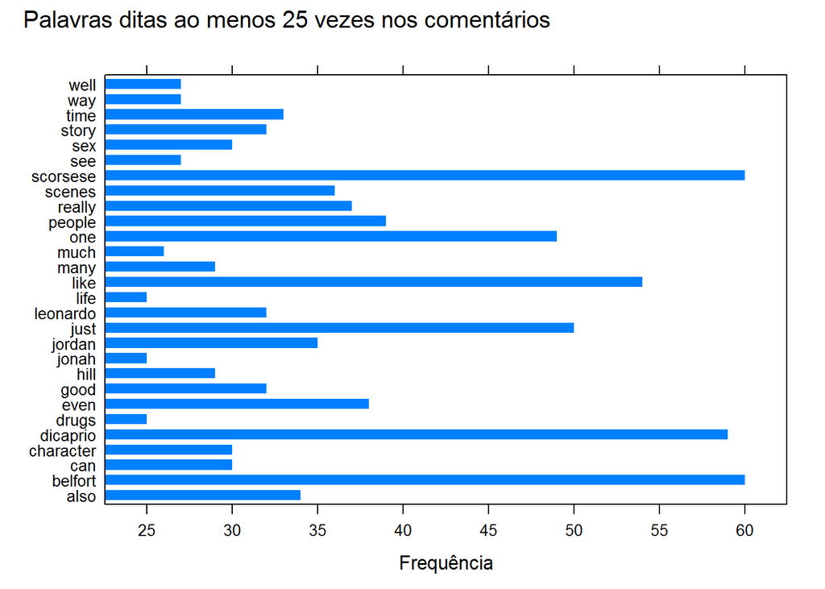

```r
# convertendo para data.frame
dataframe <- data.frame(word = names(freq), freq = freq)

# <gráfico de barras>
library(latticeExtra)

barchart(word ~ freq, subset(dataframe, freq >= 25)
         , col = "#0080ff"
         , border = "transparent"
         , scales = list(x = list(at = seq(25, 65, 5)))
         , xlab = "Frequência"
         , main = "Palavras ditas ao menos 25 vezes nos comentários"
         , par.settings = list(
           par.main.text = list(font = 1, just = "left", x = grid::unit(5, "mm"))))
```

```r
# </gráfico de barras>

# número de palavras ditas ao menos 25 vezes no comentários
nrow(subset(dataframe, freq >= 25))
```

```
[1] 28
```

Entre as palavras mais ditas estão o nome do diretor, atores e personagens principais.

Além desssas, palavras que podem estar sendo empregadas pra representar reações positivas ao filme se destacam: “well”, “like” e “good”.

Palavras que representam algumas características do filme também aparecem: “sex” e “drugs”.

Nenhuma palavra com conotação aparentemente negativa surgir entre mais ditas.

```r
# número de palavras ditas ao menos 10 vezes no comentários
nrow(subset(dataframe, freq >= 10))
```

```
[1] 115
```

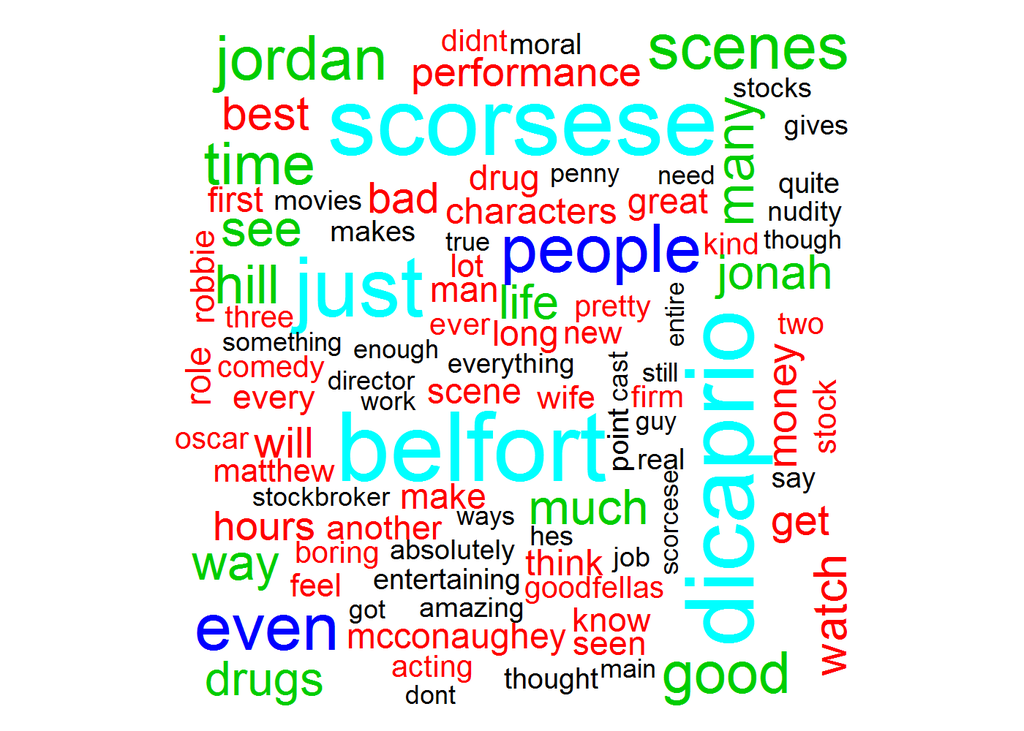

```r
# <nuvem de palavras>
library(wordcloud)

wordcloud(names(freq), freq, min.freq = 10, colors = 1:5)
```

```r
# </nuvem de palavras>
```

Com base em suas frequências as palavras que aparecem ao menos 10 vezes foram divididas em 5 intervalos, onde cada intervalo é representado por uma cor diferente.

De maneira informal podemos chamar cada intervalo de *clusters*.

*Clusters* propriamente ditos foram obtidos, contudo, dado o grande número de palavras presentes na base de dados (2724 palavras) sua visualização e entendimento ficaram inviáveis.

Aparecem palavras que expressam características do filme e reações do público, como “drugs”, “good”, “watch”, “long”, “money”, “bad”, “best”, “comedy”, “hours”, “boring”, “entertaining”, “amazing”, “oscar” e “great”.

Com base na nuvem de palavras a inferência lógica é que o filme é bom, contudo, aparenta ser longo.

Mesmo com a retirada de palavras de ligação, conjugações, etc, ainda aparecem muitas palavras irrelevantes e que fora do contexto empregado podem nos levar a diferentes conclusões.